# Introduction to R

> Reading: Faraway (2005), Appendixes A and B

```r
2+3  # R can be used as a simple calculator
exp(1)  # All the usual calculator functions are available
pnorm(1.645)  # the normal probability function
```

[output not shown]

The assignment operator is “<-”

```r
x <- 2  # assign the value 2 to x
y <- 3  # y is 3
z <- x+y  # assign the sum to z
z  # look at the result
```

```
## [1] 5
```

Vector and matrix valued variables are also possible.

The c(), cbind() and rbind() functions are useful for building these up.

```r
x <- c(1,9,7,3)  # x is a length 4 vector
x  # take a look
```

```
## [1] 1 9 7 3
```

```r
y <- 1:4  # ":" is useful for assigning a sequence
y  # take a look
```

```
## [1] 1 2 3 4
```

```r
z <- x+y # vector arithmetic works as expected
z # take a look
```

```
## [1]  2 11 10  7
```

```r
xm <- cbind(x,y,z) # make a matrix by binding x, y, z together column-wise
xm # take a look
```

```
##      x y  z
## [1,] 1 1  2
## [2,] 9 2 11
## [3,] 7 3 10
## [4,] 3 4  7
```

```r
t(xm) # the transpose of xm
```

```
##   [,1] [,2] [,3] [,4]
## x    1    9    7    3
## y    1    2    3    4
## z    2   11   10    7
```

```r
rbind(x, y, z) # make a matrix by binding x, y, z together row-wise
```

```
##   [,1] [,2] [,3] [,4]
## x    1    9    7    3
## y    1    2    3    4
## z    2   11   10    7
```

Now let’s look at getting some simple statistics:

```r
x <- rnorm(50) # generat 50 standard normal random numbers
mean(x) # the mean
```

```
## [1] 0.007517387
```

```r
var(x) # the variance
```

```
## [1] 0.7961584
```

```r
summary(x) # 5 number summary plus the mean
```

```
##      Min.   1st Qu.    Median      Mean   3rd Qu.      Max.
## -1.658000 -0.583100 -0.069190  0.007517  0.529300  1.835000
```

```r
stem(x) # a stemplot of x
```

```
##
##   The decimal point is at the |
##
##   -1 | 765
##   -1 | 11000
##   -0 | 9987665555
##   -0 | 44432210
##    0 | 02223344
##    0 | 55557789
##    1 | 1123
##    1 | 6778
```

```r
y <- rnorm(50) # more random numbers
cor(x,y) # the correlation of x and y
```

```
## [1] 0.01419
```

Now, let’s do some nice graphics:

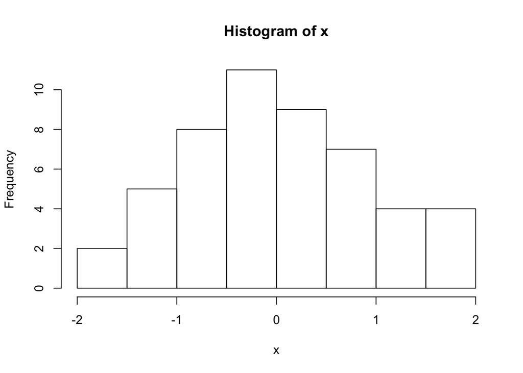

```r
hist(x) # a histogram of x
```

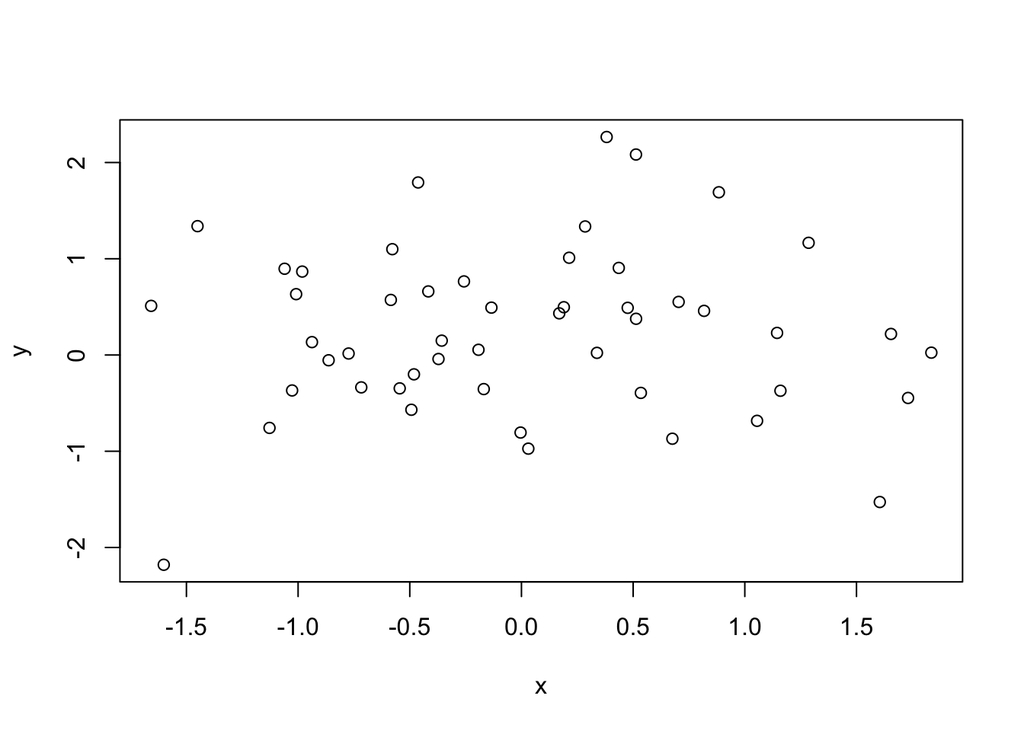

```r
plot(x,y) # a simple scatter plot
```

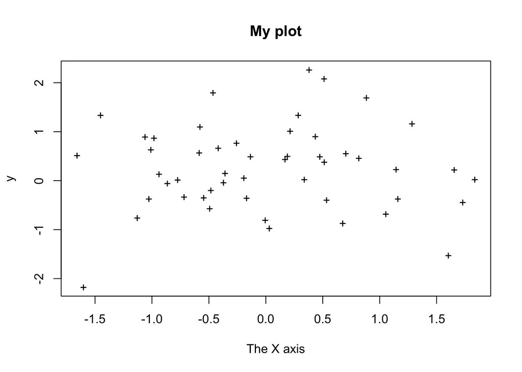

```r
plot(x,y,pch="+",xlab="The X axis",main="My plot") # add some more options to the plot
```

To find out more online use the “help()” command:

```r
help(cbind) # If you know the command you want help for
```

Lets see how we enter data into R. Here is a data set for test. You can save it as a text file to a directory, say “c:/mydata/”, with a file name, say “gala.data”.

```r
gala <- read.table("gala.data") # read the data into R
```

```r
gala # take a look
```

```
##              Species Endemics    Area Elevation Nearest Scruz Adjacent
## Baltra            58       23   25.09       346     0.6   0.6     1.84
## Bartolome         31       21    1.24       109     0.6  26.3   572.33
## Caldwell           3        3    0.21       114     2.8  58.7     0.78
## Champion          25        9    0.10        46     1.9  47.4     0.18
## Coamano            2        1    0.05        77     1.9   1.9   903.82
## Daphne.Major      18       11    0.34       119     8.0   8.0     1.84
## Daphne.Minor      24        0    0.08        93     6.0  12.0     0.34
## Darwin            10        7    2.33       168    34.1 290.2     2.85
## Eden               8        4    0.03        71     0.4   0.4    17.95
## Enderby            2        2    0.18       112     2.6  50.2     0.10
## Espanola          97       26   58.27       198     1.1  88.3     0.57
## Fernandina        93       35  634.49      1494     4.3  95.3  4669.32
## Gardner1          58       17    0.57        49     1.1  93.1    58.27
## Gardner2           5        4    0.78       227     4.6  62.2     0.21
## Genovesa          40       19   17.35        76    47.4  92.2   129.49
## Isabela          347       89 4669.32      1707     0.7  28.1   634.49
## Marchena          51       23  129.49       343    29.1  85.9    59.56
## Onslow             2        2    0.01        25     3.3  45.9     0.10
## Pinta            104       37   59.56       777    29.1 119.6   129.49
## Pinzon           108       33   17.95       458    10.7  10.7     0.03
## Las.Plazas        12        9    0.23        94     0.5   0.6    25.09
## Rabida            70       30    4.89       367     4.4  24.4   572.33
## SanCristobal     280       65  551.62       716    45.2  66.6     0.57
## SanSalvador      237       81  572.33       906     0.2  19.8     4.89
## SantaCruz        444       95  903.82       864     0.6   0.0     0.52
## SantaFe           62       28   24.08       259    16.5  16.5     0.52
## SantaMaria       285       73  170.92       640     2.6  49.2     0.10
## Seymour           44       16    1.84       147     0.6   9.6    25.09
## Tortuga           16        8    1.24       186     6.8  50.9    17.95
## Wolf              21       12    2.85       253    34.1 254.7     2.33
```

R stores whole datasets in dataframes. It’s a convenient way of keeping all the variables together.

```r
dim(gala) # check the dimension of the data
```

```
## [1] 30  7
```

You can select a variable from the data by:

```r
gala$Species # pick out a particular variable
```

```
##  [1]  58  31   3  25   2  18  24  10   8   2  97  93  58   5  40 347  51
## [18]   2 104 108  12  70 280 237 444  62 285  44  16  21
```

```r
gala$Sp # unique abbreviations work
```

```
##  [1]  58  31   3  25   2  18  24  10   8   2  97  93  58   5  40 347  51
## [18]   2 104 108  12  70 280 237 444  62 285  44  16  21
```

```r
attach(gala) # makes the prepending of gala unnecessary - see next line
Species
```

```
##  [1]  58  31   3  25   2  18  24  10   8   2  97  93  58   5  40 347  51
## [18]   2 104 108  12  70 280 237 444  62 285  44  16  21
```

You can select a subset of the data by:

```r
gala[2,] # the second row
```

```
##           Species Endemics Area Elevation Nearest Scruz Adjacent
## Bartolome      31       21 1.24       109     0.6  26.3   572.33
```

```r
gala[,3] # the third column
```

```
##  [1]   25.09    1.24    0.21    0.10    0.05    0.34    0.08    2.33
##  [9]    0.03    0.18   58.27  634.49    0.57    0.78   17.35 4669.32
## [17]  129.49    0.01   59.56   17.95    0.23    4.89  551.62  572.33
## [25]  903.82   24.08  170.92    1.84    1.24    2.85
```

```r
gala[2,3] # the (2,3) element
```

```
## [1] 1.24
```

```r
gala[c(1,2,4), ] # the first, second, and fourth rows
```

```
##           Species Endemics  Area Elevation Nearest Scruz Adjacent
## Baltra         58       23 25.09       346     0.6   0.6     1.84
## Bartolome      31       21  1.24       109     0.6  26.3   572.33
## Champion       25        9  0.10        46     1.9  47.4     0.18
```

```r
gala[3:6,] # the third through sixth rows
```

```
##              Species Endemics Area Elevation Nearest Scruz Adjacent
## Caldwell           3        3 0.21       114     2.8  58.7     0.78
## Champion          25        9 0.10        46     1.9  47.4     0.18
## Coamano            2        1 0.05        77     1.9   1.9   903.82
## Daphne.Major      18       11 0.34       119     8.0   8.0     1.84
```

```r
gala[,-c(1,2)] # "-" indicates "everything but", this keeps all data except the first two columns
```

```
##                 Area Elevation Nearest Scruz Adjacent
## Baltra         25.09       346     0.6   0.6     1.84
## Bartolome       1.24       109     0.6  26.3   572.33
## Caldwell        0.21       114     2.8  58.7     0.78
## Champion        0.10        46     1.9  47.4     0.18
## Coamano         0.05        77     1.9   1.9   903.82
## Daphne.Major    0.34       119     8.0   8.0     1.84
## Daphne.Minor    0.08        93     6.0  12.0     0.34
## Darwin          2.33       168    34.1 290.2     2.85
## Eden            0.03        71     0.4   0.4    17.95
## Enderby         0.18       112     2.6  50.2     0.10
## Espanola       58.27       198     1.1  88.3     0.57
## Fernandina    634.49      1494     4.3  95.3  4669.32
## Gardner1        0.57        49     1.1  93.1    58.27
## Gardner2        0.78       227     4.6  62.2     0.21
## Genovesa       17.35        76    47.4  92.2   129.49
## Isabela      4669.32      1707     0.7  28.1   634.49
## Marchena      129.49       343    29.1  85.9    59.56
## Onslow          0.01        25     3.3  45.9     0.10
## Pinta          59.56       777    29.1 119.6   129.49
## Pinzon         17.95       458    10.7  10.7     0.03
## Las.Plazas      0.23        94     0.5   0.6    25.09
## Rabida          4.89       367     4.4  24.4   572.33
## SanCristobal  551.62       716    45.2  66.6     0.57
## SanSalvador   572.33       906     0.2  19.8     4.89
## SantaCruz     903.82       864     0.6   0.0     0.52
## SantaFe        24.08       259    16.5  16.5     0.52
## SantaMaria    170.92       640     2.6  49.2     0.10
## Seymour         1.84       147     0.6   9.6    25.09
## Tortuga         1.24       186     6.8  50.9    17.95
## Wolf            2.85       253    34.1 254.7     2.33
```

```r
gala[gala$Sp > 300,] # select those cases whose Species are greater than 300
```

```
##           Species Endemics    Area Elevation Nearest Scruz Adjacent
## Isabela       347       89 4669.32      1707     0.7  28.1   634.49
## SantaCruz     444       95  903.82       864     0.6   0.0     0.52
```

More details on R can be found: http://www.math.montana.edu/Rweb/Rnotes/R.html.